# Flights delay in the US airports

## Introduction:

This presentation about data of January 2019. This data was collected from [**Bureau of Transportation Statistics**](https://www.transtats.bts.gov/DL_SelectFields.asp?Table_ID=236) . In this presentation we will have a look at some important insights that we acquired from our data.

### What is the most frequent day that have flights in the week?

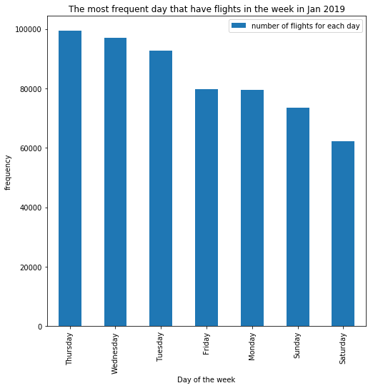

```python
# counting the repeatition of records for each day
plt.figure(figsize=(8,8))
df.index.day_name().value_counts().plot(kind='bar')
plt.title("The most frequent day that have flights in the week in Jan 2019")
plt.xlabel("Day of the week")
plt.ylabel("frequency")
plt.legend(['number of flights for each day'])
```

#### Thursday is very busy and crowded day and satuday is the lowest.

### What are the most influential factors that affects the flights cancellation?

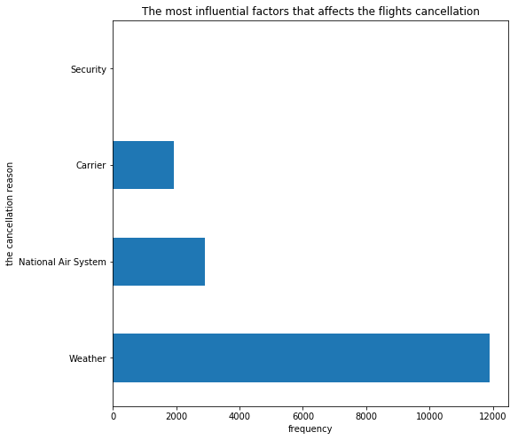

```python
# checking the most frequent cancellation reason
plt.figure(figsize=(8,8))
df["cancellation_code"].value_counts().plot(kind='barh')
plt.title("The most influential factors that affects the flights cancellation")
plt.xlabel("frequency")
plt.ylabel("the cancellation reason")
```

### We can notice that the most frequent reason for cancelaltion is weather and comes after it National Air system.

### Which day the most delays happened?

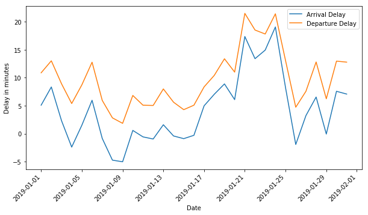

```python
plt.figure(figsize=(10,5))
plt.plot(df[["arr_delay"]].resample("d").mean())
plt.plot(df[["dep_delay"]].resample("d").mean())
plt.ylabel("Delay in minutes")
plt.xlabel("Date")
plt.legend(["Arrival Delay","Departure Delay"])
plt.xticks(rotation=45, ha='right')
```

#### It is quite obvious that Arrival and Departure Delays are very related they form together similar trends. In addition, the second half of the month witnesses higher delays than the first half.

## Does cancellation of flights in one day affects the next day?

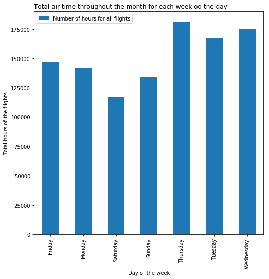

```python
plt.figure(figsize=(8,8))
(df.groupby("day_of_week")["air_time"].sum()/60).plot(kind='bar')
plt.title("Total air time throughout the month for each week od the day",loc='left')
plt.ylabel("Total hours of the flights")
plt.xlabel("Day of the week")
plt.legend(["Number of hours for all flights"])
```

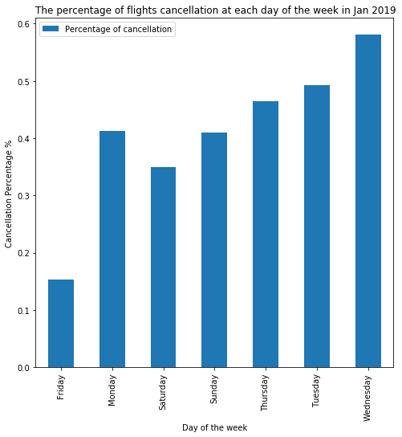

```python
# checking which day has the highest cancellation and dirversion rate
plt.figure(figsize=(8,8))
(df.loc[df.cancelled==1].groupby('day_of_week')["cancelled"].count()/len(df)  *100).plot(kind='bar')
plt.title("The percentage of flights cancellation at each day of the week in Jan 2019",loc='left')
plt.ylabel("Cancellation Percentage %")
plt.xlabel("Day of the week")
plt.legend(["Percentage of cancellation"])
```

#### The air time is at its highest on Thursday, and on the other side cancellations of Wednesday are more than Thursday. Does a cancellation of flights on a day affects the next day? in order to answer this question, more data should be collected.

## Conclusion:

- Thursday is a busy day.
- Weather is the highest reason behind cancellation of flights.
- Departure and arrival delays are highly related.
- It is hard to determine if cancellation of flights in one day affects the next day without enough data.